# HDXBoxeR

Maria K. Janowska, Katherine Reiter, Pearl Magala, Miklos Guttman, Rachel E. Klevit

4/2/2024

HDX-MS is a high-information-content method. It is both a curse and a blessing. A lot can be learned, but data analysis is tedious, as each experiment in HDX-MS provides information on hundreds of peptides. Each experiment should be done at least in triplicate. Very often, multiple time points for each protein state are performed. Finally, multiple protein states are compared, as the goal of performing HDX-MS is often to compare how ligand binding or mutation affects the wild-type apo protein state. This can easily lead to a dataset with multiple thousand peptides that need to be matched between the sets compared and deemed statistically relevant or not. HDXBoxeR provides a statistical framework to identify peptides that are significantly different between given protein states. HDXBoxeR automatically matches and compares sets with each other. It calculates if one protein state is different from another using Welch’s T-test and the Critical Interval statistical framework (Hageman and Weis; Anal. Chem. 2019, 91, 13, 8008–8016). It allows for fast data export and generates scripts for Pymol. Finally, it returns all the calculations required for publication, as recommended by Masson et al. in Nature Methods volume 16, pages 595–602 (2019).

HDXBoxeR facilitates multiple aspects of HDX data analysis:

1. Reprocesses data to the format required for data publication.
2. Calculates parameters for a general HDX summary table, such as backexchange, peptide lengths, and statistical information required for data publication.
3. Converts the output from HDXExaminer (Sierra Analytics, now Trajan Scientific) to a format that is easier to handle and analyze.
4. Using Welch T-tests, it identifies peptides that are significantly different between the sets.
5. Generates scripts for Pymol.
6. Facilitates easy plot generation, including heat maps, robot plot (modified butterfly plot), significant peptides, volcano plots, and average deuteration.
7. Generates inputs for ExtReme. The package allows for comparison between different protein states and facilitates the discrimination of peptides that are significantly different between the sets.

# How to use this vignette?

The vignette is divided into several sections that introduce different aspects of analysis:

1. Input Preparation: Learn how to prepare inputs for HDXBoxeR in HDXExaminer.
2. Installation: Get started and set up the necessary components.
3. Inputs Reprocessing: Understand how to prepare inputs to be usable in R.
4. Statistical Analysis: Explore which peptides are significant.
5. Plots Generation: Visualize the peptides deemed significant.
6. Pymol Scripts Generation: Create scripts listing significant peptides and residues.
7. Data Summary: Obtain general information about the dataset.
8. Save Data: Save data in the reprocessed format.
9. ExtReme Outputs Generation: Automatically prepare input for bimodal analysis.
10. Proposed Workflow: A section for those in a hurry. These changes aim to enhance consistency in language and formatting across the different sections.

## 1. Input preparation

The HDXBoxeR requires data! The package can be tested using the data included as a reference and example with the package, so don’t worry. However, to be able to perform your analysis, you need to import your data into R. Input for the HDXBoxeR should be generated using HDXExaminer from Sierra Scientifics.

### Input preparation

Input preparation: 1. Open your HDexaminer file. 2. Under the Peptides tab > Pool > right-click peptide: delete peptides with no usable data. 3. Tools > Options > Display > Deuteration Table: Display all columns (we did not select show low-confidence results). 4. Tools > Export > All results table.

The example looks as follows:

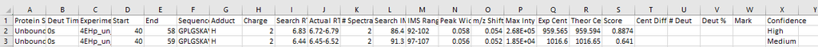

The input file should have the following columns: Protein State, Deut Time, Experiment, Start, End, Sequence, Charge, Search RT, # Deut, Deut %. If any of these columns is missing data will not be loaded. Another thing to make sure of is that the columns are properly aligned, meaning there is the name number of headers and columns, as sometimes the Confidence column gets shifted in the AllResultsTable.csv file. We keep typically just peptides with high and medium confidence. Example data compares two Protein States: Unbound and Bound. Each of the sets has three replicates. Data also should have one replicate of undeuterated and fully deuterated sets labeled as 0s and FD respectively for allowing full analysis.

## 2. Installation & Loading

First, ensure that you have R and RStudio installed on your computer. Then you can proceed with the installation of the HDXBoxeR package. There are two methods to install the HDXBoxeR package:

1. CRAN

To install, use the following command:

```r
####installation using CRAN
install.packages("HDXBoxeR") #execute only once
```

2. GitHub

The HDXBoxeR package is available on GitHub and can be installed using the devtools package. This method of installation is an alternative to the CRAN method.

```r
####installation using Github.
#run only if devtools package is not installed on your machine
install.packages("devtools")

library(devtools) #run next two commends only once
devtools::install_github("mkajano/HDXBoxeR")

#Once installed, you can load the HDXBoxeR package using the following command:
library(HDXBoxeR)
```

## 3. How to load data into R

To load data into R, you will need input as described in section 1. Example input is provided as a reference, and to start the fun. Data, when loaded, will be reprocessed into different formats depending on the type of analysis to be performed. There are several options in which input can be processed, as listed below. Function names reflect the chosen option.

Input can be formatted to:

- Analyze time points *or* time courses analysis (`output_tp` vs `output_tc` functions).
- Analyze Deuterons Uptake *or* Percent Deuteration (flag `percent=F/T`).
- Use all protein states/deuteration times *or* use selected (options: `states` and `times`, respectively).
- Use a maximum common number of replicates used *or* specify how many replicates should be used (`replicates` option in the function).
- Match Peptide sequence between protein states *or* not. Default is set to match peptide sequences to prevent mismatches; use functions with flag `match_seq`.

Examples:

```r
# Path to example input
library(HDXBoxeR)
file_nm<-system.file("extdata", "All_results_table.csv", package = "HDXBoxeR")
### Later change the path to the path you your data!!!

##########Deuteration uptake vs percent deuteration file preparation
#### Input for uptake deuteration. Default will use all common states, all common Deuteration Times, max. common number of replicates, no csv will be written, and peptide sequences will be matched.
input_uptake_timepoint<-output_tp(filepath = file_nm)
```

```
#> Protein.States used: Unbound bound
#>
#> Deut.times used: 3.00s 60.00s 1800.00s 72000.00s
#>
#> Number of replicates used: 3
#>
#> no csv file written
```

```r
# input for percent deuteration
input_deut_timepoint<-output_tp(filepath = file_nm, percent=T)
```

```
#> Protein.States used: Unbound bound
#>
#> Deut.times used: 3.00s 60.00s 1800.00s 72000.00s
#>
#> Number of replicates used: 3
#>
#> no csv file written
```

```r
#################
####Time courses
#Deuteration uptake
input_uptake_timecourse<-output_tc(file_nm)
```

```
#> Protein.States used: Unbound bound
#>
#> Deut.times used: 3.00s 60.00s 1800.00s 72000.00s
#>
#> Number of replicates used: 3
#>
#> no csv file written
```

```r
# Time courses comparisons
input_deut_timecourse<-output_tc(file_nm, percent=T)
```

```
#> Protein.States used: Unbound bound
#>
#> Deut.times used: 3.00s 60.00s 1800.00s 72000.00s
#>
#> Number of replicates used: 3
#>
#> no csv file written
```

```r
#################
####Analyze selected protein.states, deuteration times, replicates.
names_states<- nm_states(file_nm) ## returns names of the states in file.
input_two_states_two_timepoints<-output_tp(filepath=file_nm, replicates=3, states=names_states[c(1,2)], times=c("3.00s", "72000.00s"),  percent=FALSE)
```

```
#> Deut.times used: 3.00s 72000.00s
#>
#> Number of replicates used: 3
#>
#> no csv file written
```

```r
###add option to match sequence and to save as csv (here not used)
input_subset_states<-output_tp(filepath=file_nm, replicates=3, states=names_states[2], times=c("3.00s", "72000.00s"), percent=FALSE, seq_match=FALSE, csv="NA")
```

```
#> Deut.times used: 3.00s 72000.00s
#>
#> Number of replicates used: 3
#>
#> no csv file written
```

**Now that the data is loaded let’s start the fun!**

## 4. Statistical Analysis

Great! Now that the hardest part is done, let’s delve into the actual analysis.

**HDXBoxeR provides a statistical framework to identify peptides that are significantly different between given protein states.** To conduct statistics, we recommend providing at least 3 replicates for each protein state (duplicate data also work). **The number of replicates and Deut Time will be trimmed to be the same for all Protein States in the analysis.**

### Some theoretical details about statistical analysis

HDXBoxeR employs a hybrid statistical approach using the Welch T-test and Critical interval statistical framework proposed by Hageman and Weis (Hageman and Weis; Anal. Chem. 2019, 91, 13, 8008–8016). To be deemed significantly different, peptides must meet significance criteria on both the individual peptide level (Welch T-test) and surpass the global critical interval for all peptides in the set.

### Practical Tips for Statistical Analysis in HDXBoxeR

Most of the statistical analysis is already implemented in plot and other functions, but it is good to have a way to do it yourself if needed. HDXBoxeR allows for the facile calculation of averages and the standard deviation for each set. Additionally, it allows for the calculation of global and individual critical intervals.

**Individual p-values for each peptide are calculated against the first protein state based on the location from the input file. If the user desires calculation against different protein states, it can be done by loading HDXExaminer, taking advantage of the `states` parameter in `output_tp()` or `output_tc()` functions.**

```r
library(HDXBoxeR)
file_nm<-system.file("extdata", "All_results_table.csv", package = "HDXBoxeR")
input_uptake_timepoint<-output_tp(filepath = file_nm)
```

```
#> Protein.States used: Unbound bound
#>
#> Deut.times used: 3.00s 60.00s 1800.00s 72000.00s
#>
#> Number of replicates used: 3
#>
#> no csv file written
```

```r
###average calculation for all peptides
av1<-ave_timepoint(input_uptake_timepoint)
head(av1)
```

```
#>   Deut.Time Start End             Sequence Search.RT Charge av_Unbound_X..Deut
#> 1     3.00s    40  58  GPLGSKAVVPGPAEHPLQY      6.83      2           8.327667
#> 2     3.00s    40  59 GPLGSKAVVPGPAEHPLQYN      6.44      2           8.717333
#> 3     3.00s    47  63    VVPGPAEHPLQYNYTFW     10.86      2           3.974667
#> 4     3.00s    62  77     FWYSRRTPGRPTSSQS      6.12      3           7.820667
#> 5     3.00s    63  77      WYSRRTPGRPTSSQS      5.33      3           7.625333
#> 6     3.00s    64  77       YSRRTPGRPTSSQS      4.64      2           7.799333
#>   av_bound_X..Deut
#> 1         7.013667
#> 2         7.468667
#> 3         2.785667
#> 4         7.779333
#> 5         7.788667
#> 6         7.635333
```

```r
###average differences (against first Protein State in the file)
da1<-dif_ave(av1)

###standard deviation calculation for all peptides
sd1<-sd_timepoint(input_uptake_timepoint)
head(sd1)
```

```
#>   Deut.Time Start End             Sequence Search.RT Charge sd_Unbound_X..Deut
#> 1     3.00s    40  58  GPLGSKAVVPGPAEHPLQY      6.83      2         0.13838473
#> 2     3.00s    40  59 GPLGSKAVVPGPAEHPLQYN      6.44      2         0.15430597
#> 3     3.00s    47  63    VVPGPAEHPLQYNYTFW     10.86      2         0.10868456
#> 4     3.00s    62  77     FWYSRRTPGRPTSSQS      6.12      3         0.13059990
#> 5     3.00s    63  77      WYSRRTPGRPTSSQS      5.33      3         0.22095324
#> 6     3.00s    64  77       YSRRTPGRPTSSQS      4.64      2         0.05689757
#>   sd_bound_X..Deut
#> 1       0.05379901
#> 2       0.10442382
#> 3       0.04764801
#> 4       0.08114391
#> 5       0.01357694
#> 6       0.03754109
```

```r
### Global critical interval for 1 protein sets
CI_single(s1 =sd1[,7], replicates = 3 )
```

```
#> [1] 0.1789317
```

```r
##Global critical interval for 2 protein sets
CI_2pts(s1 = sd1[,7], s2=sd1[,8], replicates = 3)
```

```
#> [1] 0.2706825
```

```r
##individual peptide p-value calculation against first set in the input file
pv1<-pv_timepoint(input_uptake_timepoint)
head(pv1)
```

```
#>   Deut.Time Start End             Sequence Search.RT Charge pv_Unbound_X..Deut
#> 1     3.00s    40  58  GPLGSKAVVPGPAEHPLQY      6.83      2                  1
#> 2     3.00s    40  59 GPLGSKAVVPGPAEHPLQYN      6.44      2                  1
#> 3     3.00s    47  63    VVPGPAEHPLQYNYTFW     10.86      2                  1
#> 4     3.00s    62  77     FWYSRRTPGRPTSSQS      6.12      3                  1
#> 5     3.00s    63  77      WYSRRTPGRPTSSQS      5.33      3                  1
#> 6     3.00s    64  77       YSRRTPGRPTSSQS      4.64      2                  1
#>   pv_bound_X..Deut
#> 1     0.0012982057
#> 2     0.0006305205
#> 3     0.0006958101
#> 4     0.6701607913
#> 5     0.3287217910
#> 6     0.0188970633
```

```r
####Analyze selected protein.states, deuteration times, replicates.
names_states<- nm_states(file_nm) ## returns names of the states in file.
### choosing different state as a control for analysis
input_states_reversed<-output_tp(file_nm, states=names_states[c(2,1)] )
```

```
#> Deut.times used: 3.00s 60.00s 1800.00s 72000.00s
#>
#> Number of replicates used: 3
#>
#> no csv file written
```

```r
pv2<-pv_timepoint(input_states_reversed)
head(pv2)
```

```
#>   Deut.Time Start End             Sequence Search.RT Charge pv_bound_X..Deut
#> 1     3.00s    40  58  GPLGSKAVVPGPAEHPLQY      6.83      2                1
#> 2     3.00s    40  59 GPLGSKAVVPGPAEHPLQYN      6.44      2                1
#> 3     3.00s    47  63    VVPGPAEHPLQYNYTFW     10.86      2                1
#> 4     3.00s    62  77     FWYSRRTPGRPTSSQS      6.12      3                1
#> 5     3.00s    63  77      WYSRRTPGRPTSSQS      5.33      3                1
#> 6     3.00s    64  77       YSRRTPGRPTSSQS      4.64      2                1
#>   pv_Unbound_X..Deut
#> 1       0.0012982057
#> 2       0.0006305205
#> 3       0.0006958101
#> 4       0.6701607913
#> 5       0.3287217910
#> 6       0.0188970633
```

### States, Replicates, Timepoints, etc.

There are a few variables that are going to be useful while analyzing the data. It might be a good idea to have them saved in the memory. One can call them as follows:

```r
###load data

states<-arguments_call1(filepath=file_nm)
times<-arguments_call2(filepath=file_nm, states=states)
replicates<-arguments_call3(filepath=file_nm, states=states, times=times)
```

### Sub-setting of the Input Table

Sometimes, we do not want to work on or plot the whole imported dataset. One can either load a smaller subset or choose a part of the subset from the loaded dataset to work on. The already loaded data can be subsetted using the `select_indices` function or by choosing desired columns from the loaded data. In the loaded data, the first 6 columns always describe peptides, and the rest of the columns contain data.

```r
#################
####Time courses
#Deuteration uptake
input_uptake_timecourse<-output_tc(file_nm)
```

```
#> Protein.States used: Unbound bound
#>
#> Deut.times used: 3.00s 60.00s 1800.00s 72000.00s
#>
#> Number of replicates used: 3
#>
#> no csv file written
```

```r
# Time courses comparisons

small_df1<-input_uptake_timepoint[,c(1:6, 10:12)]

#if one wants to focus just on the few first peptides in the data it is possible to select a few rows from the input data.
small_df2<-input_uptake_timepoint[1:3,]

#To have more control of the selecting one can also use the select_indices functions as follows:
##for output_tp function variables that can be used are:
#below one time of 60s was used for peptides that started at residue 50, ended at residue 100 and  at the max 12 residues long.
#not all parameters need to be used.
inda<-select_indices(input_uptake_timepoint,  times = c("60.00s"),start = 50, end=100, length=12)

#after the indices are selected the input can be subsetted as normal

small_df3<-input_uptake_timepoint[inda,]

##for the output_tc function allowed are the following parameters
timecourse_output<-output_tc(file_nm)
```

```
#> Protein.States used: Unbound bound
#>
#> Deut.times used: 3.00s 60.00s 1800.00s 72000.00s
#>
#> Number of replicates used: 3
#>
#> no csv file written
```

```r
indb<-select_indices(timecourse_output,  states = "bound",start = 50, end=100, length=12)

head(timecourse_output[indb,1:6])
```

```
#>       Sequence Protein.State Start End Search.RT Charge
#> 16 YEQNIKQIGTF         bound    78  88      7.61      2
#> 18     IKQIGTF         bound    82  88      6.81      2
#> 20   ASVEQFWRF         bound    89  97     10.72      2
```

## 5. Plots

HDXBoxeR features functionality to create various types of plots, including volcano plots, heat maps, and robot plots (modified butterfly plots).

**Information on how to load input into HDXBoxeR can be found in section 3.** If the returned plots have truncated labels, adjust the figure sizes.

### Uptake Plots

Sometimes, it is just useful to look at raw-ish data. Uptake plots are the answer here.

```r
###load data
library(HDXBoxeR)
file_nm<-system.file("extdata", "All_results_table.csv", package = "HDXBoxeR")
input_deut_timepoint<-output_tc(file_nm, percent=TRUE)
```

```
#> Protein.States used: Unbound bound
#>
#> Deut.times used: 3.00s 60.00s 1800.00s 72000.00s
#>
#> Number of replicates used: 3
#>
#> no csv file written
```

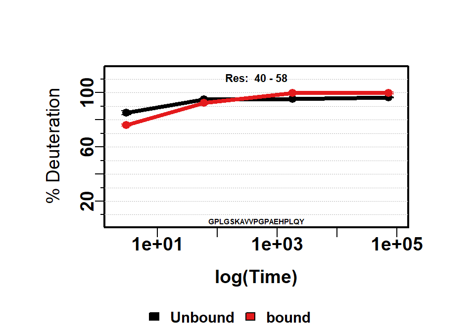

```r
# define the timepoint using in the experiment. Here the times in seconds
x<-c(3, 60,1800, 72000)
uptake_plots(input_deut_timepoint[1:2,],x)
```

### Boxplots

Boxplots enable quick comparisons of average uptake or percent deuteration for all protein states.

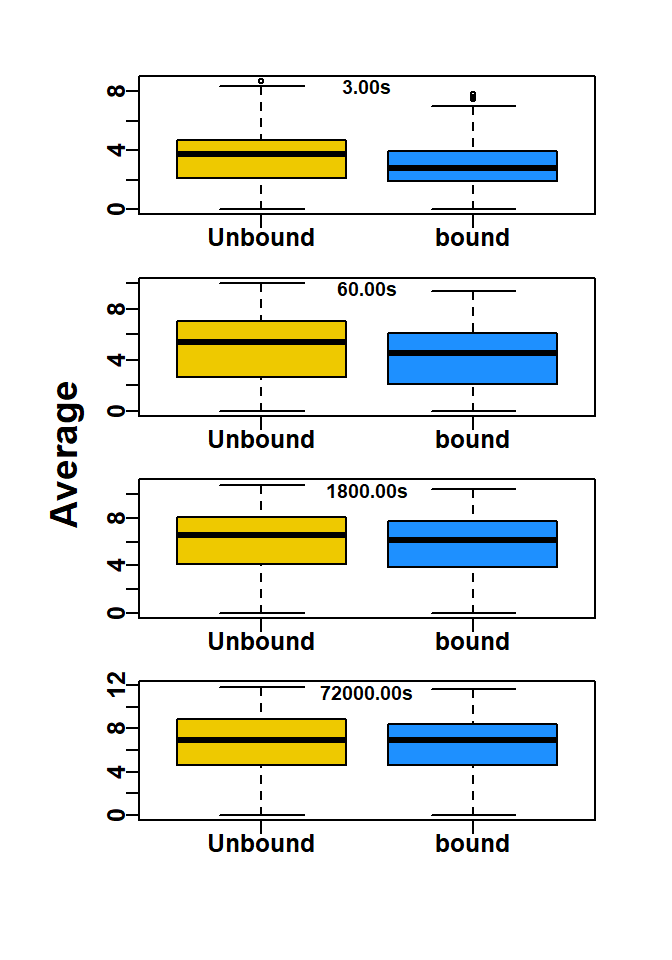

```r
###load data
# library(HDXBoxeR)
# file_nm<-system.file("extdata", "All_results_table.csv", package = "HDXBoxeR")
# input_uptake_timepoint<-output_tp(file_nm)


### Returns boxplots for all the time points and all protein states.
boxplot_tp(input_uptake_timepoint, col= c("gold2", "dodgerblue"))
```

### Average uptake and procent deuteration plots per time-point

```r
###load data
library(HDXBoxeR)
file_nm<-system.file("extdata", "All_results_table.csv", package = "HDXBoxeR")
# ## input for deuteration uptakeinput_uptake_timepoint<-output_tp(file_nm)
# # input for procent deuteration
input_deut_timepoint<-output_tp(file_nm, percent=T)
```

```
#> Protein.States used: Unbound bound
#>
#> Deut.times used: 3.00s 60.00s 1800.00s 72000.00s
#>
#> Number of replicates used: 3
#>
#> no csv file written
```

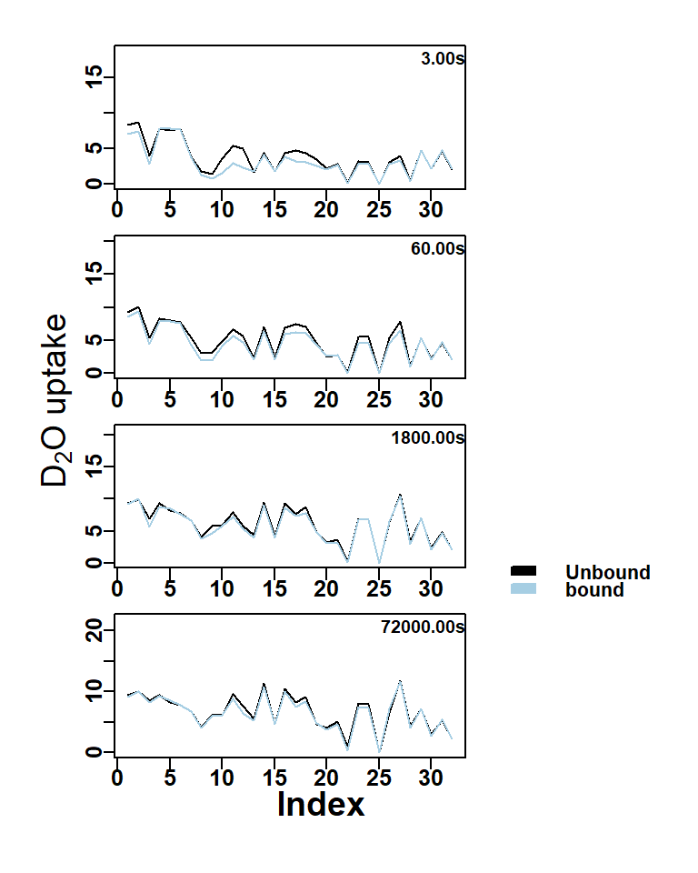

```r
## deuteration uptake for time points
plots_av_tp(input_uptake_timepoint)
```

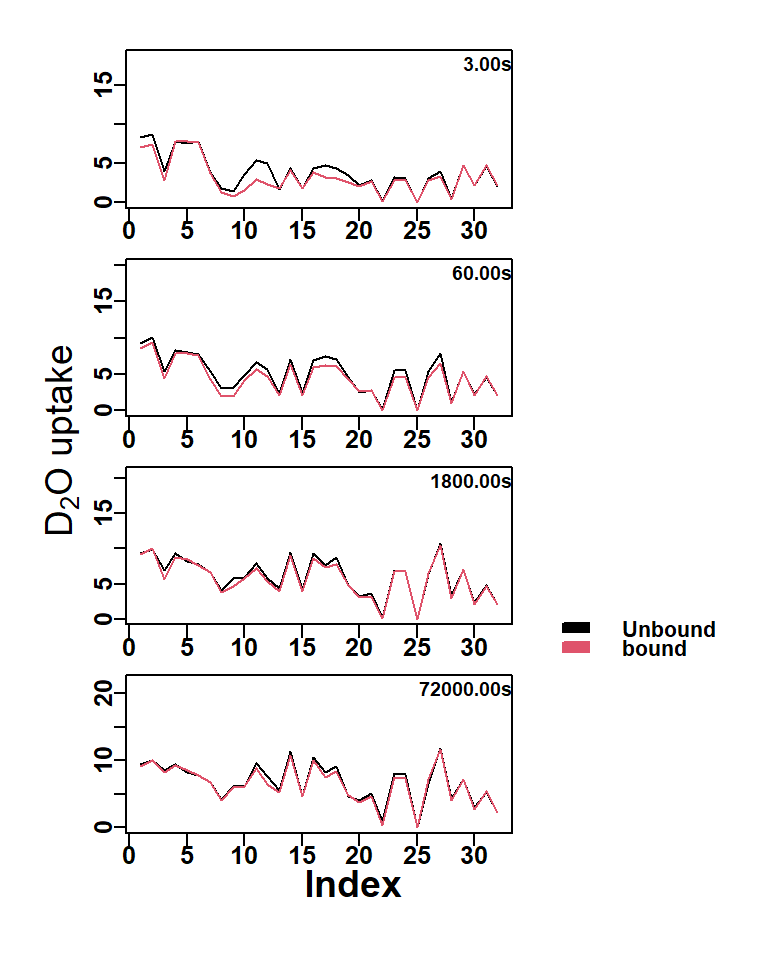

```r
### average plots with colors chosen by user.
plots_av_tp(input_uptake_timepoint,replicates=3, cola=c(1:10))
```

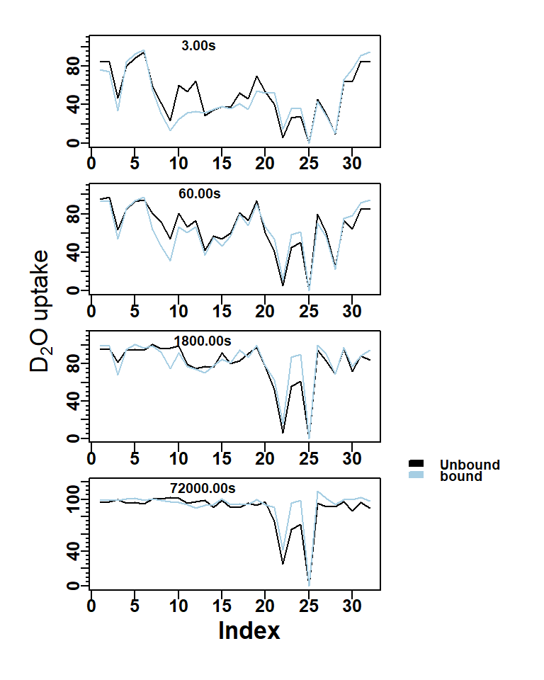

```r
### average percent deuteration
plots_av_tp_proc(input_deut_timepoint)
```

### Difference Uptake or Percent Deuteration Plots per Time-point

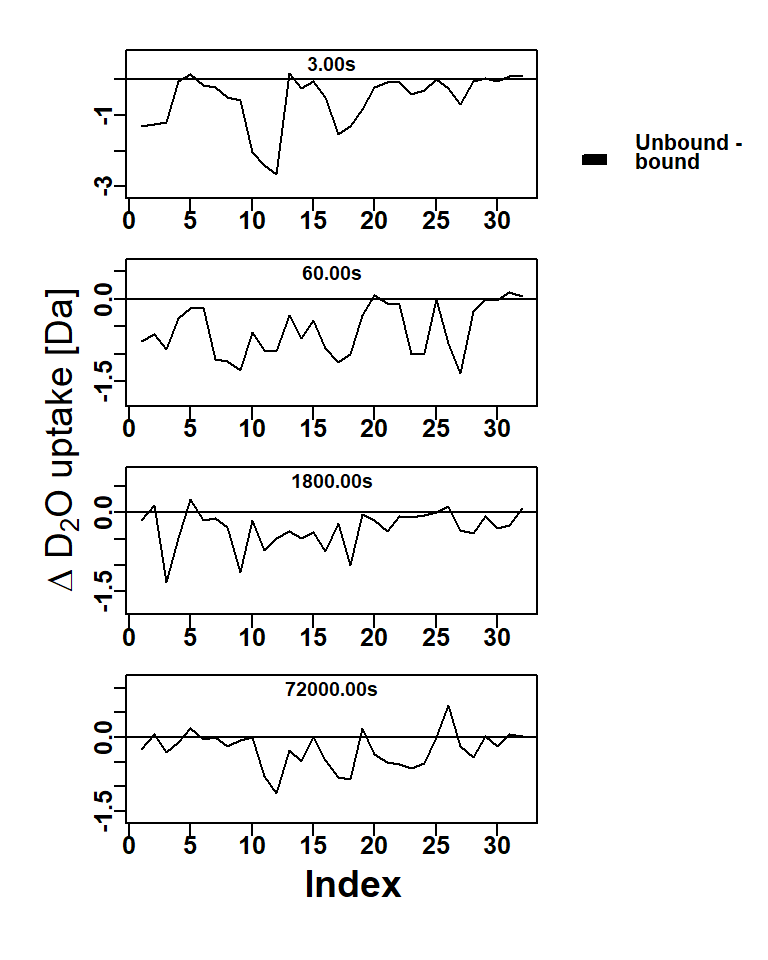

```r
# ###load data
# file_nm<-system.file("extdata", "All_results_table.csv", package = "HDXBoxeR")
# ## input for deuteration uptake
# input_uptake_timepoint<-output_tp(file_nm)


## difference in uptake deuterations between two sets
plots_diff_tp(input_uptake_timepoint)
```

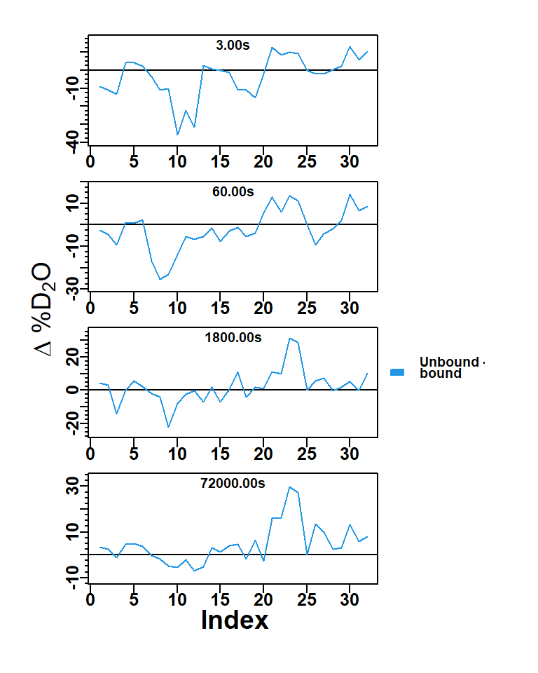

```r
#Load deut data
# input for procent deuteration
# input_deut_timepoint<-output_tp(file_nm, percent=T)

### difference in procent deuteration
plots_diff_tp_proc(input_deut_timepoint,replicates=3, cola=4)
```

```r
#input with different order states
names_states<- nm_states(file_nm)
input_reversed_states<-output_tp(file_nm, states = rev(names_states))
```

```
#> Deut.times used: 3.00s 60.00s 1800.00s 72000.00s
#>
#> Number of replicates used: 3
#>
#> no csv file written
```

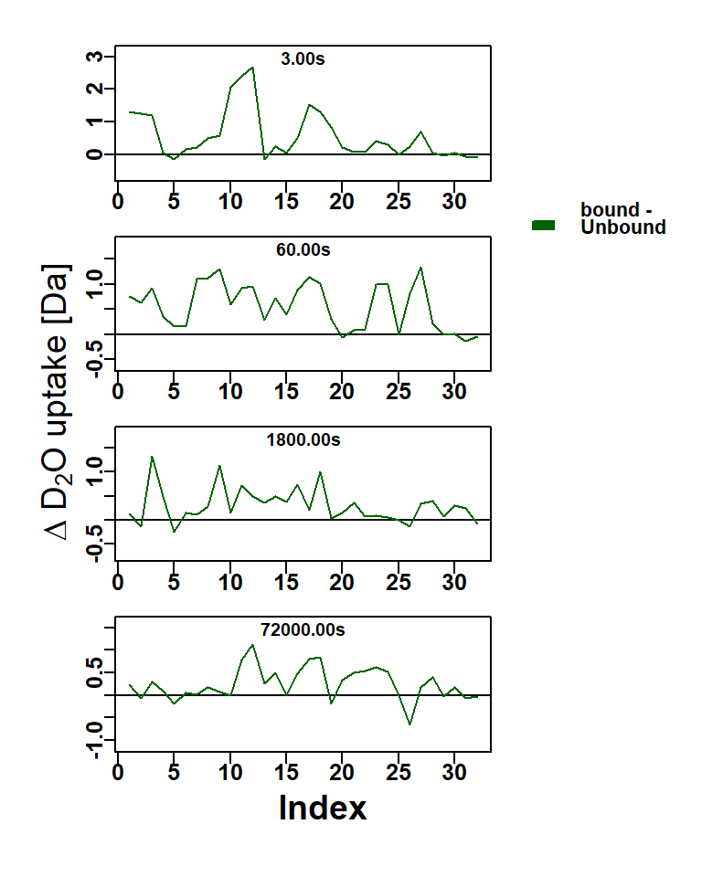

```r
### average plots for deuteration uptake where control state was chosen differently
plots_diff_tp(input_reversed_states, col="darkgreen")
```

### Volcano Plots

Volcano plots were introduced by the Weis laboratory (Analytical Chemistry 2019, 91 (13), 8008-8016 DOI: 10.1021/acs.analchem.9b01325). The strength of the volcano plots is that they allow for a quick view to see how many peptides are between the sets and provide statistics for the differences. The Volcano plots take advantage of the p-value and critical interval calculation. The p-value is calculated per each peptide using the Welch t-test for the desired number of replicates. The global critical interval is calculated as described in Hageman and Weis (Analytical Chemistry 2019, 91 (13), 8008-8016 DOI: 10.1021/acs.analchem.9b01325). As the default alpha is set to 0.99, the p-value cut off is marked by horizontal lines, and the global critical interval by vertical lines. Significantly different peptides between the sets are located in the shaded area. The volcano plots are only prepared for differences in deuterons uptake. The critical intervals for all time-points are returned in the terminal.

```r
###load data
file_nm<-system.file("extdata", "All_results_table.csv", package = "HDXBoxeR")
## input for deuteration uptake
a<-output_tp(file_nm)
```

```
#> Protein.States used: Unbound bound
#>
#> Deut.times used: 3.00s 60.00s 1800.00s 72000.00s
#>
#> Number of replicates used: 3
#>
#> no csv file written
```

```
#> CI @ 3.00s : 0.35
#> CI @ 60.00s : 0.27
#> CI @ 1800.00s : 0.24
#> CI @ 72000.00s : 0.2
```

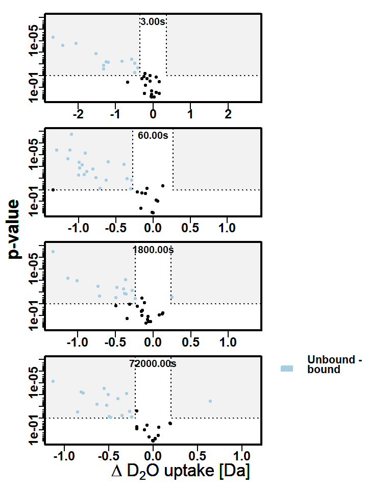

```r
### basic volcano plot
plots_vol_tp(a)
```

```
#> CI @ 3.00s : 0.35
#> CI @ 60.00s : 0.27
#> CI @ 1800.00s : 0.24
#> CI @ 72000.00s : 0.2
```

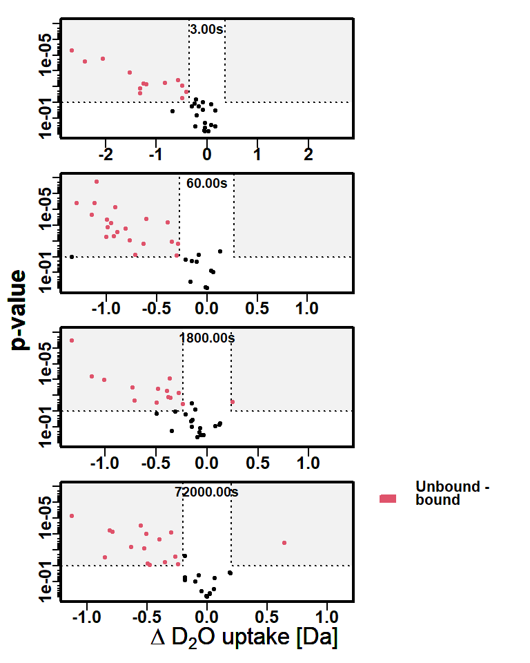

```r
# change colors for significant peptides in volcano plots
plots_vol_tp(a, cola=c(2,3), replicates=3)
```

```
#> CI @ 3.00s : 0.16
#> CI @ 60.00s : 0.13
#> CI @ 1800.00s : 0.11
#> CI @ 72000.00s : 0.09
```

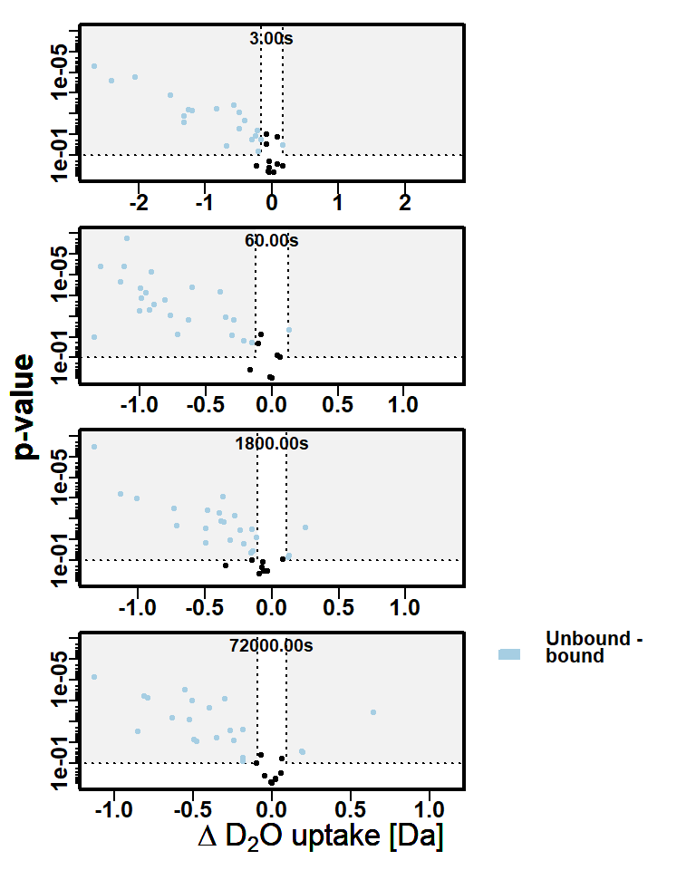

```r
#change pv_cutoff from 0.01 to 0.1
plots_vol_tp(a, pv_cutoff = 0.1)
```

### Significant Peptides Mapped Along Residue Sequence

The significant peptides plots draw peptides along the covered sequence of the protein. Peptides deemed significantly different using the Welch test and the global critical interval criterion are colored in a red-blue scheme. Red-colored peptides are more exposed compared to the control set, while blue colors correspond to increased protection compared to the control set. Non-significant peptides are colored black.

The plots can be drawn using either percent deuteration or deuteration uptake input sets. If the percent deuteration input is used, the difference between the two sets is colored according to the chosen scheme (function `plot_peptide_sig_tp_proc`). If using deuteration uptake input, data is converted to percents using the equation: `(Uptake(state1) - Uptake(state2)) / Uptake(state1) * 100%` (function: `plot_peptide_sig_tp`).

Percent differences are divided into ranges, each corresponding to a specific color in the red-blue color scheme. Range values can be changed as desired within the red-blue color scheme. In the terminal, ranges for each set are returned to help choose ranges of the color scheme.

Plots are generated separately for each time-point and each pair of the difference values (State1-State2, State1-State3…). The `plot_peptide_sig_tp` generates multiple plots, which usually calls for using the plotting parameter `mfrow`.

```r
###load data
file_nm<-system.file("extdata", "All_results_table.csv", package = "HDXBoxeR")
## input for deuteration uptake
a<-output_tp(file_nm)
```

```
#> Protein.States used: Unbound bound
#>
#> Deut.times used: 3.00s 60.00s 1800.00s 72000.00s
#>
#> Number of replicates used: 3
#>
#> no csv file written
```

```
#> For timepoint 3.00s
#> values range from  0 to 5.68 %
#> Unbound bound range 0 5.68
#> For timepoint 60.00s
#> values range from  -0.28 to 4.04 %
#> Unbound bound range -0.28 4.04
```

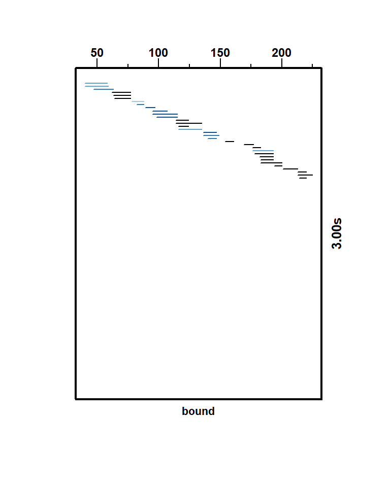

```
#> For timepoint 1800.00s
#> values range from  -0.31 to 1.96 %
#> Unbound bound range -0.31 1.96
```

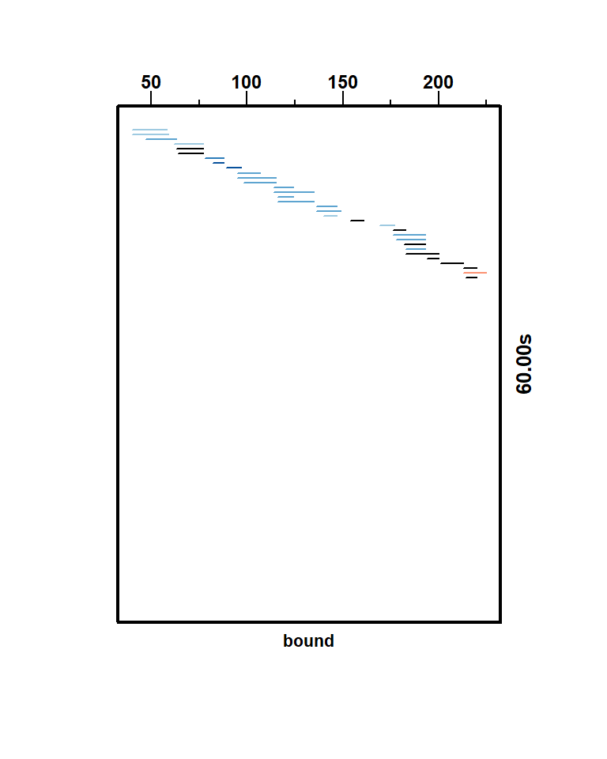

```
#> For timepoint 72000.00s
#> values range from  -0.99 to 6.01 %
#> Unbound bound range -0.99 6.01
```

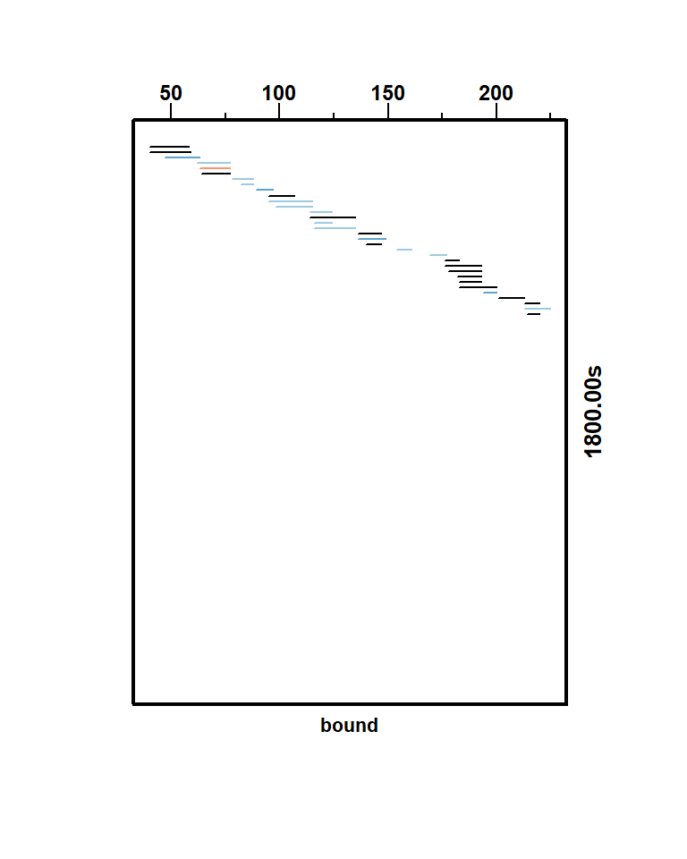

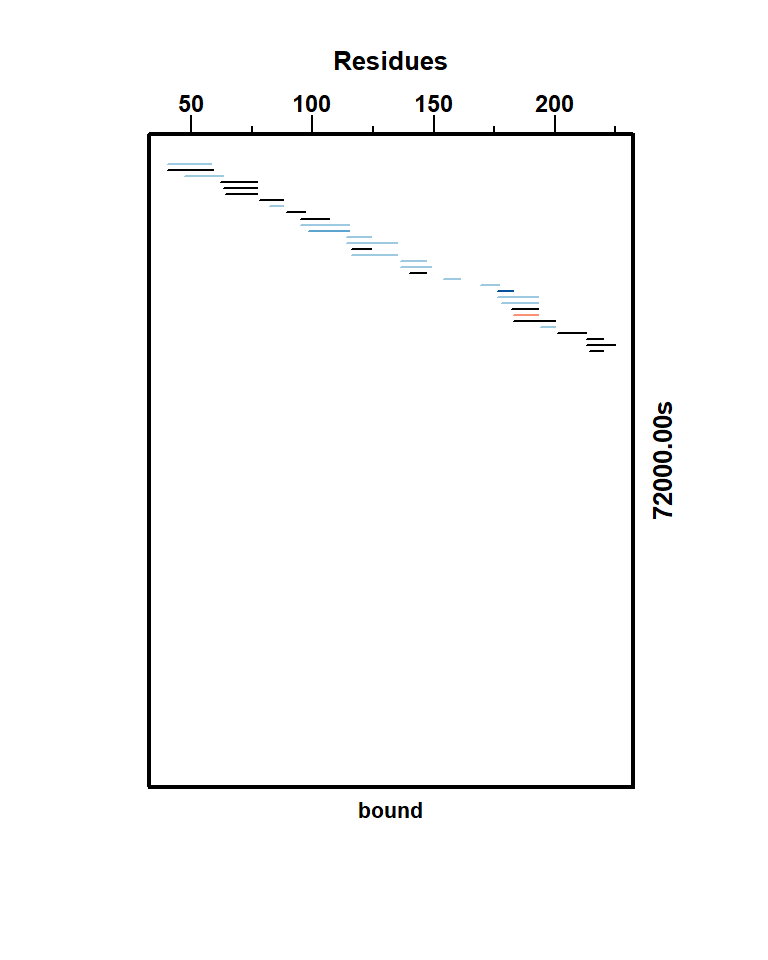

```r
### significantly different peptides are colored in red-blue scheme.

#par(mfrow=c(4,1))  # uncomment if desired
plot_peptide_sig_tp(a,replicates = 3)
```

```
#> For timepoint 3.00s
#> values range from  0 to 5.68 %
#> Unbound bound range 0 5.68
#> For timepoint 60.00s
#> values range from  0 to 4.04 %
#> Unbound bound range 0 4.04
```

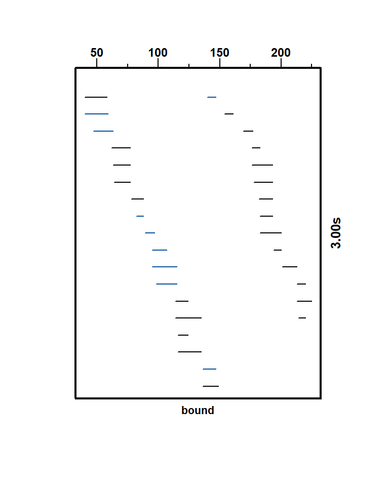

```
#> For timepoint 1800.00s
#> values range from  0 to 1.96 %
#> Unbound bound range 0 1.96
```

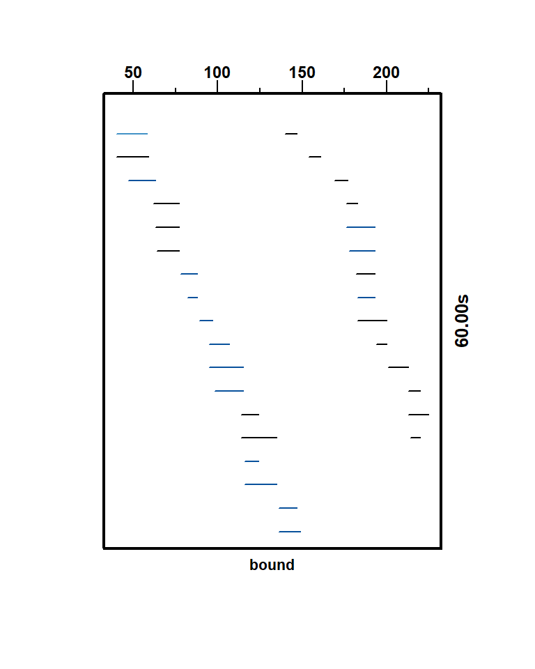

```
#> For timepoint 72000.00s
#> values range from  -0.99 to 1.49 %
#> Unbound bound range -0.99 1.49
```

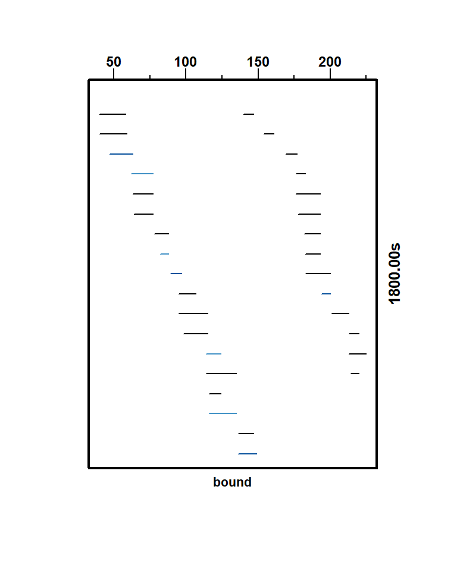

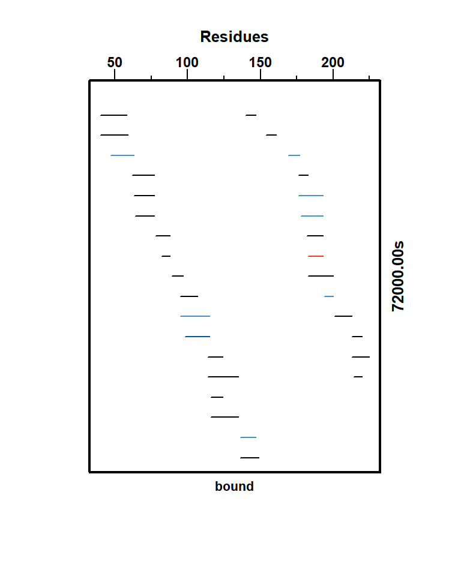

```r
### Plot where 18 peptides per row are drawn (nb_pep_row=18, default=50),
#p-value&critial interval was made more stingent (0.001)
# % ranges are colored were changed.
#par(mfrow=c(4,1)) #uncomment if desired
plot_peptide_sig_tp(a,nb_pep_row = 18, ranges = c(-Inf, -10, -2.5,0,2.5, 10, Inf), pv_cutoff = 0.001)
```

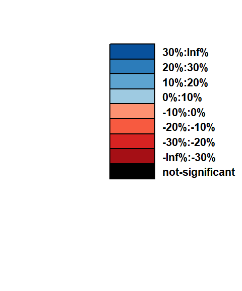

```r
## Legend for significant peptides plot
#default ranges for figures does not require argument
legend_sig_peptides()
```

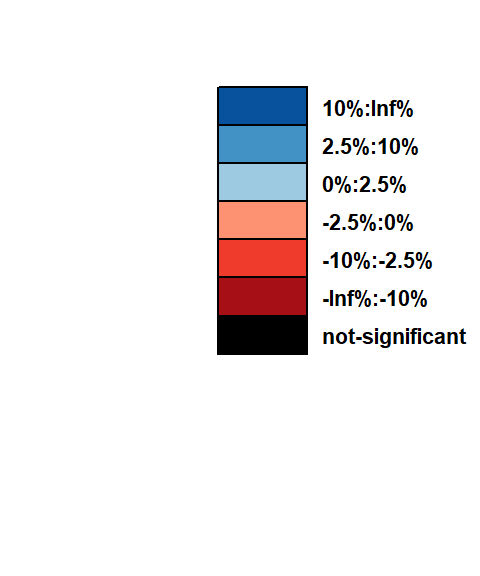

```r
### Using different range scheme
legend_sig_peptides(ranges = c(-Inf, -10, -2.5,0,2.5, 10, Inf))
```

### Differential heat maps

Differential Heat Maps are plots where peptides significantly different between the sets are translated into residue-specific information. Heat maps are a fast, highly informative, and elegant way to see which regions are perturbed in the sets. However, it means that some information is lost (coverage). There are two options on how these calculations are performed:

1. Average uptake of all significant peptides containing that residue is calculated.
2. Maximum uptake value from all peptides classified as significant with that residue in its sequence.

Differential heat maps can be calculated using the difference in percent deuteration between two sets or uptake of (control - other sets) / (uptake of control) * 100.

The example scheme for how average uptake and maximum uptake per residue are generated is shown below.

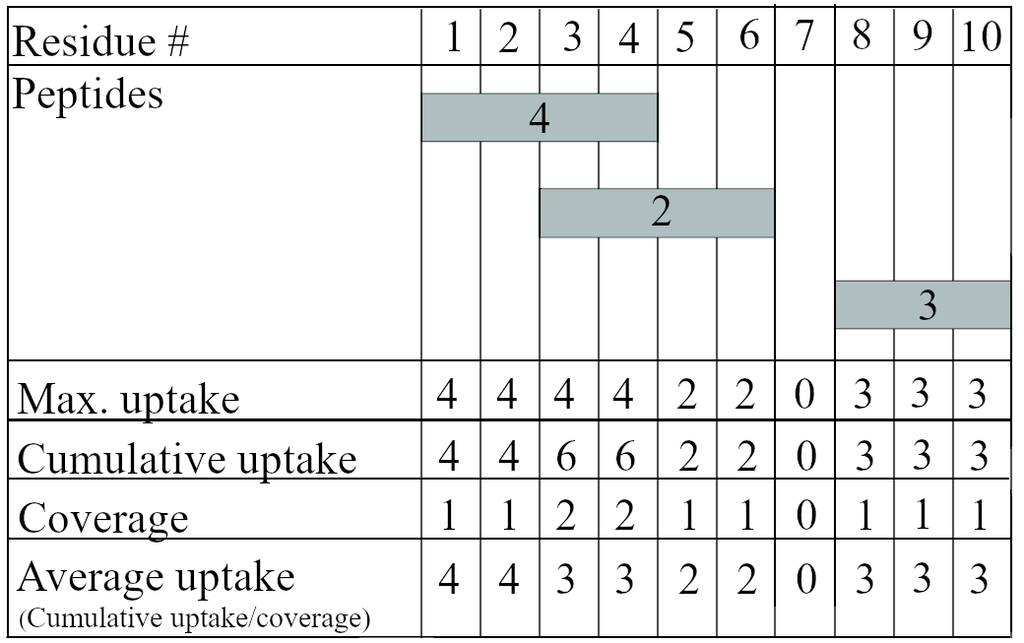

```r
###load data
library(HDXBoxeR)
file_nm<-system.file("extdata", "All_results_table.csv", package = "HDXBoxeR")
## input for deuteration uptake
a<-output_tp(file_nm)
```

```
#> Protein.States used: Unbound bound
#>
#> Deut.times used: 3.00s 60.00s 1800.00s 72000.00s
#>
#> Number of replicates used: 3
#>
#> no csv file written
```

```r
# input for procent deuteration
b<-output_tp(file_nm, percent=T)
```

```
#> Protein.States used: Unbound bound
#>
#> Deut.times used: 3.00s 60.00s 1800.00s 72000.00s
#>
#> Number of replicates used: 3
#>
#> no csv file written
```

```
#> For time point 3.00s
#> values range from  0 to 10.35 %
#> Unbound bound range 0 10.35
#> For time point 60.00s
#> values range from  -0.28 to 6.71 %
#> Unbound bound range -0.28 6.71
#> For time point 1800.00s
#> values range from  0 to 3.11 %
#> Unbound bound range 0 3.11
#> For time point 72000.00s
#> values range from  0 to 2.81 %
#> Unbound bound range 0 2.81
```

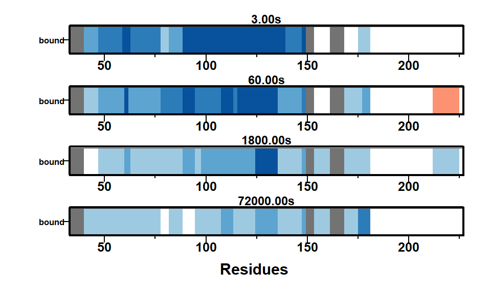

[output not shown]

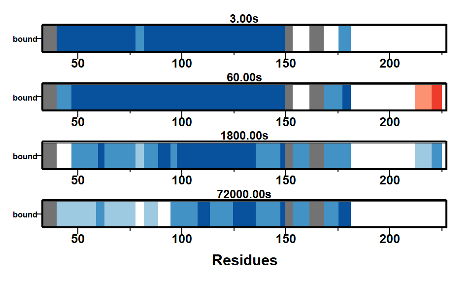

```
#> NULL

### heat map for percent deuteration, require both uptake and percent deuteration data frame as input
plot_heat_map_tp_proc(input_up = a, input_proc = b, replicates=3)
#> For time point 3.00s
#> values range from  -3.29 to 50.26 %
#> Unboun boun range -3.29 50.26
#> For time point 60.00s
#> values range from  -12.66 to 33.38 %
#> Unboun boun range -12.66 33.38
#> For time point 1800.00s
#> values range from  -11.17 to 21.97 %
#> Unboun boun range -11.17 21.97
#> For time point 72000.00s
#> values range from  -29.95 to 4.58 %
#> Unboun boun range -29.95 4.58
```

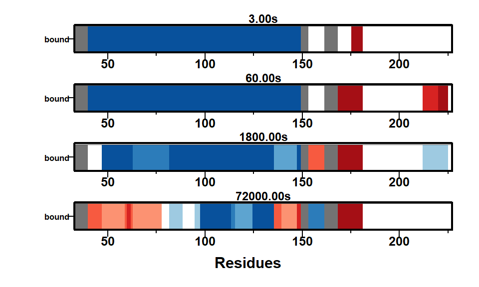

```r
##Average uptake heat maps
### heat maps
plot_heat_map_tp(a, replicates=3, mar_x=3)
```

```
#> For timepoint 3.00s
#> values range from  0 to 5.68 %
#> Unbound bound range 0 5.68
#> For timepoint 60.00s
#> values range from  -0.28 to 4.04 %
#> Unbound bound range -0.28 4.04
#> For timepoint 1800.00s
#> values range from  0 to 1.96 %
#> Unbound bound range 0 1.96
#> For timepoint 72000.00s
#> values range from  -0.99 to 6.01 %
#> Unbound bound range -0.99 6.01
```

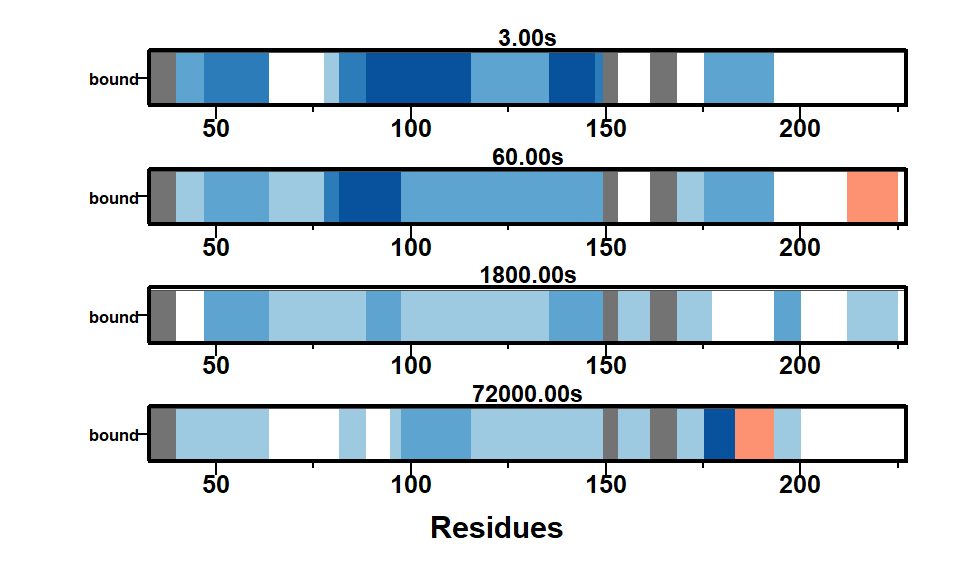

```
#> NULL
### #
plot_heat_map_max_uptake_tp_proc(input_up = a, input_proc = b, replicates=3, mar_x=1, ranges = c(-Inf, -10, -2.5,0,2.5, 10, Inf), pv_cutoff=0.01)
#> For time point 3.00s
#> values range from  -9.86 to 35.61 %
#> Unboun boun range -9.86 35.61
#> For time point 60.00s
#> values range from  -13.3 to 25.36 %
#> Unboun boun range -13.3 25.36
#> For time point 1800.00s
#> values range from  -11.17 to 21.97 %
#> Unboun boun range -11.17 21.97
#> For time point 72000.00s
#> values range from  -29.81 to 7 %
#> Unboun boun range -29.81 7
```

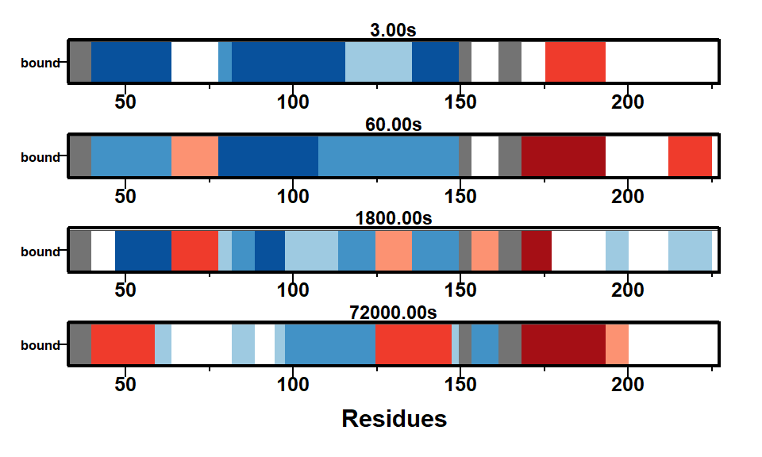

```r
###Maximum uptake or percent deuteration per peptide
plot_heat_map_max_uptake_tp(a, replicates=3)
```

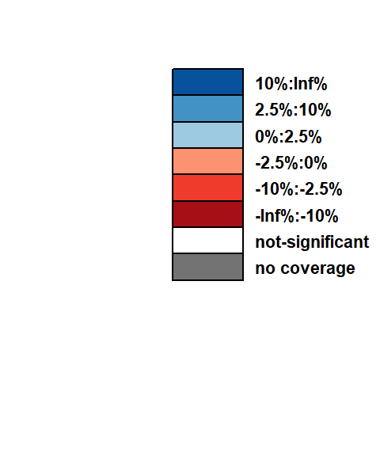

```r
## Legend for the heatmaps.
#default ranges for figures does not require argument
legend_heat_map(ranges = c(-Inf, -10, -2.5,0,2.5, 10, Inf))
```

### Woods Plots

Woods plots come in two flavors: one that looks at the time course or timepoints. Below are examples. The usage of the `subset_indices` is highly recommended.

```r
##
file_nm<-system.file("extdata", "All_results_table.csv", package = "HDXBoxeR")


tp_aP<-output_tp(filepath = file_nm, percent=T) #timepoints
```

```
#> Protein.States used: Unbound bound
#>
#> Deut.times used: 3.00s 60.00s 1800.00s 72000.00s
#>
#> Number of replicates used: 3
#>
#> no csv file written
```

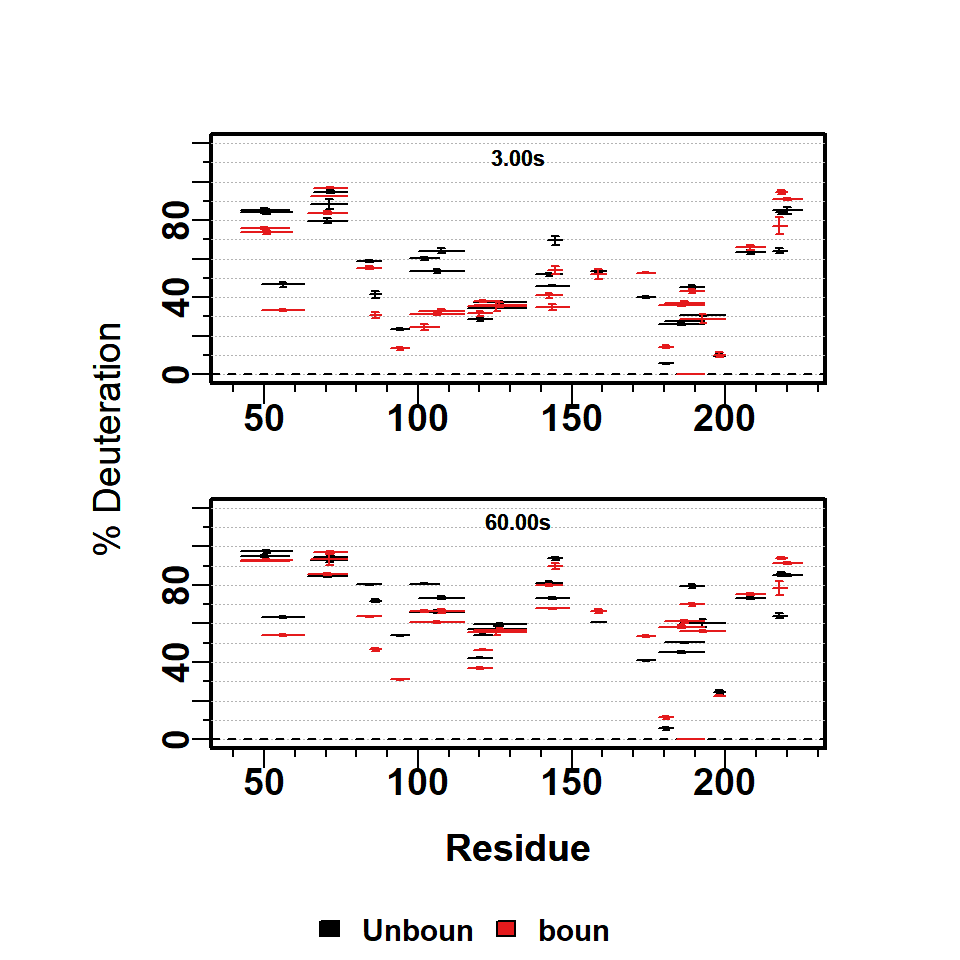

```r
indp<-select_indices(tp_aP,  times = c("3.00s", "60.00s"))
deuteration_woods_timepoints(tp_aP[indp,], replicates = 3)
```

```r
## input for timecourses
tc_aP<-output_tc(filepath = file_nm, percent=T) #timecourse
```

```
#> Protein.States used: Unbound bound
#>
#> Deut.times used: 3.00s 60.00s 1800.00s 72000.00s
#>
#> Number of replicates used: 3
#>
#> no csv file written
```

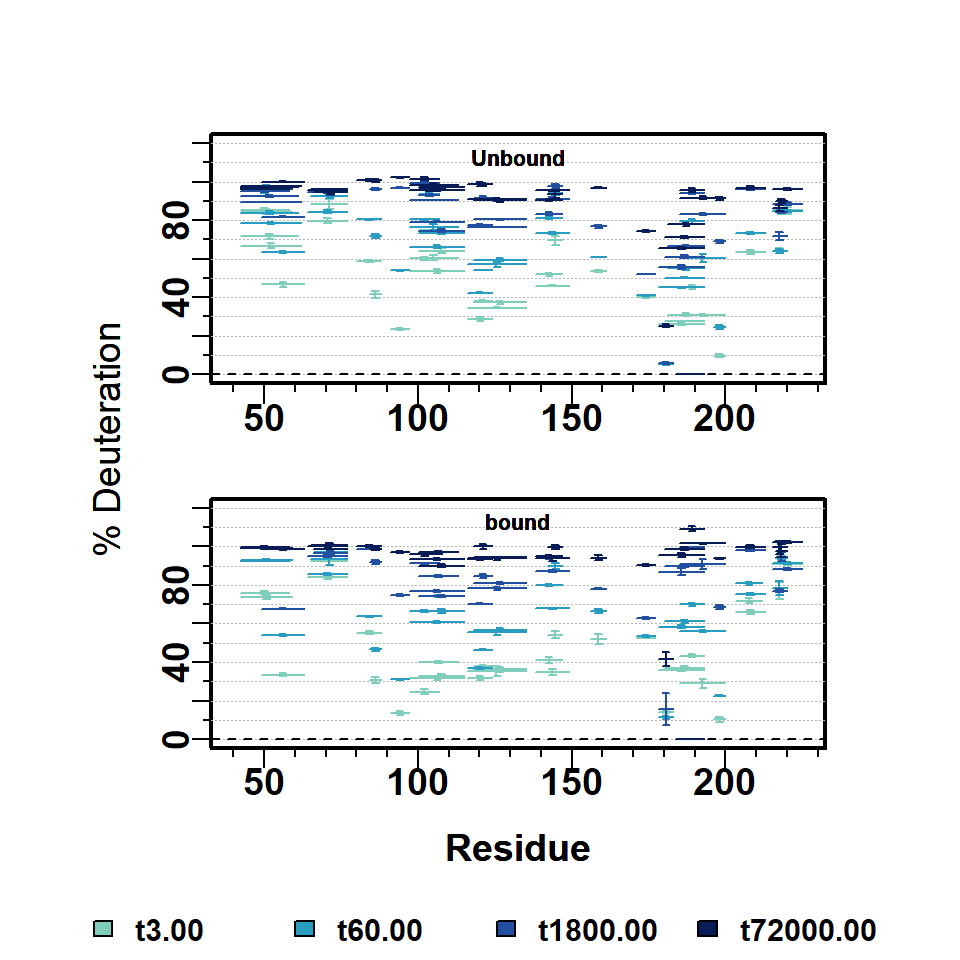

```r
deuteration_woods_timecourse(tc_aP, replicates=3)
```